# POC replicate table 3 of the previous paper by analysing the effect of density

# Objective(s)

Replicate table 3 of the previous paper

https://drive.google.com/uc?export=view&id=1hmtmIb6BF4zBg4NIgNzTqT4HqETcdA-G

- Column 1 is the baseline column with the main fixed effect:
  - city-product-regime: fe_ckr
  - city-sector-regime-year: fe_csrt
  - product-year: fe_kt
- Columns 2 and 3 split the dataset into Eligible and Non eligible. Fixed effect are :
  - city-product: fe_ck
  - city-sector-year: fe_cst
  - product-destination: fe_pj
- Column 4 include Comparative advantages with the main fixed effect:
  - city-product-regime: fe_ckr
  - city-sector-regime-year: fe_csrt
  - product-year: fe_kt
- Comparative advantage should be computed in the notebook with R. The code will be provided
- Repeat with and without export share covariates

# Metadata

- Epic: Epic 2
- US: US 3
- Date Begin: 10/5/2020
- Duration Task: 1
- Description: Replicate table 3 with and without the export share covariates
- Step type:
- Status: Active
- Source URL:
- Task type: Jupyter Notebook
- Users: Thomas Pernet
- Watchers: Thomas Pernet
- User Account: https://468786073381.signin.aws.amazon.com/console
- Estimated Log points: 10
- Task tag: #density,#econometrics,#ols
- Toggl Tag: #model-training
- Meetings:
- Email Information:
  - thread: Number of threads: 0(Default 0, to avoid display email)

# Input Cloud Storage [AWS/GCP]

## Table/file

- Origin:
- Athena
- S3
- Name:
  - quality_vat_export_covariate_2003_2010
  - ADDITIONAL_DATA/BACI
  - ADDITIONAL_DATA/DENSITY
  - import_export
- Github:
  - https://github.com/thomaspernet/VAT_rebate_quality_china/blob/master/01_data_preprocessing/02_prepare_tables_model/02_transform_table_baseline_covariates.md
  - https://github.com/thomaspernet/VAT_rebate_quality_china/blob/master/01_data_preprocessing/00_download_data_from_/BACI/baci_92_2002.py
  - https://github.com/thomaspernet/VAT_rebate_quality_china/blob/master/01_data_preprocessing/00_download_data_from_/DENSITY/density.py
  - https://github.com/thomaspernet/VAT_rebate_quality_china/blob/master/01_data_preprocessing/01_prepare_tables/01_tables_trade_tariffs_taxes.md

# Connexion server

```python
from awsPy.aws_authorization import aws_connector
from awsPy.aws_s3 import service_s3
from awsPy.aws_glue import service_glue
from pathlib import Path
import pandas as pd
import numpy as np
#import seaborn as sns
import os, shutil

path = os.getcwd()
parent_path = str(Path(path).parent.parent.parent)


name_credential = 'thomas_vat_credentials.csv'
region = 'eu-west-3'
bucket = 'chinese-data'
path_cred = "{0}/creds/{1}".format(parent_path, name_credential)
```

```python
os.environ['KMP_DUPLICATE_LIB_OK']='True'
```

```python
con = aws_connector.aws_instantiate(credential = path_cred,
                                       region = region)
client= con.client_boto()
s3 = service_s3.connect_S3(client = client,
                      bucket = bucket, verbose = False)
glue = service_glue.connect_glue(client = client)
```

```python
pandas_setting = True
if pandas_setting:
    #cm = sns.light_palette("green", as_cmap=True)
    pd.set_option('display.max_columns', None)
    pd.set_option('display.max_colwidth', None)
```

```python
#density\_china\_ville:ln\_lag\_import\_tax
change_import_tax_order <- function(table){
    check_three_int <- grep("density_china_ville:regimeELIGIBLE:ln_lag_import_tax$", rownames(table$coef))
    check_two_int <- grep("density_china_ville:ln_lag_import_tax$", rownames(table$coef))
    check_two_eligible <- grep("^regimeELIGIBLE:balassa$", rownames(table$coef))

    if (length(check_three_int) !=0) {
    rownames(table$coefficients)[check_three_int] <- 'ln_lag_import_tax:density_china_ville:regimeELIGIBLE'
    rownames(table$beta)[check_three_int] <- 'ln_lag_import_tax:density_china_ville:regimeELIGIBLE'
}
    if (length(check_two_int) !=0) {
    rownames(table$coefficients)[check_two_int] <- 'ln_lag_import_tax:density_china_ville'
    rownames(table$beta)[check_two_int] <- 'ln_lag_import_tax:density_china_ville'
}
    if (length(check_two_eligible) !=0) {
    rownames(table$coefficients)[check_two_eligible] <- 'balassa:regimeELIGIBLE'
    rownames(table$beta)[check_two_eligible] <- 'balassa:regimeELIGIBLE'
}

    return (table)
}
```

# Load tables

Since we load the data as a Pandas DataFrame, we want to pass the `dtypes`. We load the schema from Glue to guess the types

- Filename:
  - Main table S3: https://s3.console.aws.amazon.com/s3/buckets/vat-rebate-quality/DATA/TRANSFORMED/?region=eu-west-3&tab=overview
  - Density: https://s3.console.aws.amazon.com/s3/buckets/chinese-data/ADDITIONAL_DATA/DENSITY/?region=eu-west-3&tab=overview
  - baci: https://s3.console.aws.amazon.com/s3/buckets/chinese-data/ADDITIONAL_DATA/BACI/?region=eu-west-3&tab=overview
- Export 2002 from Athena

```python
download_data = False
db = 'chinese_trade'
if download_data:

    s3.download_file(
        key = 'ADDITIONAL_DATA/DENSITY/density.Rda',
    path_local = os.path.join(str(Path(path).parent.parent.parent),
                              "00_data_catalogue/temporary_local_data")
)
    s3.download_file(
        key = 'ADDITIONAL_DATA/BACI/baci92_2002.csv',
    path_local = os.path.join(str(Path(path).parent.parent.parent),
                              "00_data_catalogue/temporary_local_data")
)

    s3 = service_s3.connect_S3(client = client,
                          bucket = 'vat-rebate-quality', verbose = False)
    query  = """
    WITH trade AS (
      SELECT
        date as year,
        CASE WHEN length(hs) < 5 THEN CONCAT('0', hs) ELSE hs END as hs6,
        value,
        city_prod,
        geocode4_corr
      FROM
        chinese_trade.import_export
        INNER JOIN chinese_lookup.city_cn_en ON import_export.city_prod = city_cn_en.citycn
      WHERE
        date = '2002'
    )
    SELECT
      year,
      hs6,
      geocode4_corr,
      CAST(SUM(value) AS DECIMAL(16,5))/1000 as total_value_city
    FROM
      trade
    GROUP BY
      year,
      hs6,
      geocode4_corr

    """

    output = s3.run_query(
            query=query,
            database=db,
            s3_output='SQL_OUTPUT_ATHENA',
            filename=None,  # Add filename to print dataframe
            destination_key=None # Add destination key if need to copy output
        )

    s3.copy_object_s3(
    source_key = os.path.join('SQL_OUTPUT_ATHENA', "{}.csv".format(output['QueryID'])),
    destination_key = "DATA/TRANSFORMED/export_2002.csv",
    remove = True
)

    s3.download_file(
        key = 'DATA/TRANSFORMED/export_2002.csv',
    path_local = os.path.join(str(Path(path).parent.parent.parent),
                              "00_data_catalogue/temporary_local_data")
)
```

# Models to estimate

## Fixed Effect

| Benchmark | Origin | Name | Description | Math_notebook |
| --- | --- | --- | --- | --- |
| Yes | Current | city-product |  | $\alpha_{ck}$ |
| Yes | Current | city-product-regime |  | $\alpha_{ck}^R$ |
| Yes | Current | city-sector-year | Sector is defined as GBT 4 digit | $\alpha_{cst}$ |
| Yes | Current | city-sectorーregime-year | Sector is defined as GBT 4 digit | $\alpha_{cst}^R$ |
| Yes | Current | product-destination |  | $\alpha_{pj}$ |
| Yes | Previous baseline | Product-year | account for all factors that affect product-level export irrespective of the trade regime in a given year | $\alpha_{pt}$ |
| No | Previous baseline | firm-product-eligibility | captures all the factors that affect firms regardless of the time and type of regime. This firm‒product pair eliminates the demand shocks that firms face and that are not correlated with the types of … | $\alpha^{E}_{it}$ |
| No | Previous baseline | HS4-year-eligibility |  | $\alpha^{E}_{st}$ |
| No | Previous baseline | city-year | captures the differences in demand, capital intensity, or labor supply that prevail between cities each year | $\alpha_{ct}$ |
| No | Candidate | destination-year | Captures additional level of control, encompassing all the shocks and developments in the economies to which China exports. | $\alpha_{dt}$ |

- city-product: `fe_ck`
- City-sector-year: `fe_cst`
- City-product-regime: `fe_ckr`
- City-sector-regime-year: `fe_csrt`
- Product-year: `fe_kt`
- Product-destination: `fe_pj`
- Destination-year: `fe_jt`

```python
import function.latex_beautify as lb

%load_ext autoreload
%autoreload 2
```

```python
options(warn=-1)
library(tidyverse)
library(lfe)
#library(lazyeval)
library('progress')
path = "function/table_golatex.R"
source(path)
```

```
 Hlavac, Marek (2018). stargazer: Well-Formatted Regression and Summary Statistics Tables.

 R package version 5.2.2. https://CRAN.R-project.org/package=stargazer
```

Load R dataset: https://stackoverflow.com/questions/5577221/how-can-i-load-an-object-into-a-variable-name-that-i-specify-from-an-r-data-file

```python
loadRData <- function(fileName){
#loads an RData file, and returns it
    load(fileName)
    get(ls()[ls() != "fileName"])
}
```

## Compute RCA

In this part, we use the previous code to compute the RCA.

$$ \frac{\sum_{\mathrm{d}} \mathrm{x}_{\mathrm{isd}} / \sum_{\mathrm{d}} \mathrm{X}_{\mathrm{sd}}}{\sum_{\mathrm{wd}} \mathrm{x}_{\mathrm{iwd}} / \sum_{\mathrm{wd}} \mathrm{X}_{\mathrm{wd}}} $$

Where s is the country of interest, d and w are the set of all countries in the world, i is the sector of interest, x is the commodity export flow and X is the total export flow. The numerator is the share of good i in the exports of country s, while the denominator is the share of good i in the exports of the world.

What does it tell us? Comparative advantage underlies economists’ explanations for the observed pattern of inter-industry trade. In theoretical models, comparative advantage is expressed in terms of relative prices evaluated in the absence of trade. Since these are not observed, in practice we measure comparative advantage indirectly. Revealed comparative advantage indices (RCA) use the trade pattern to identify the sectors in which an economy has a comparative advantage, by comparing the country of interests’ trade profile with the world average.

Definition: The RCA index is defined as the ratio of two shares. The numerator is the share of a country’s total exports of the commodity of interest in its total exports. The denominator is share of world exports of the same commodity in total world exports. Range of values: Takes a value between 0 and +∞. A country is said to have a revealed comparative advantage if the value exceeds unity. Limitations: The index is affected by anything that distorts the trade pattern, e.g., trade barriers.

```python
path_rca <- "../../../00_Data_catalogue/temporary_local_data/baci92_2002.csv"
path_export <- "../../../00_Data_catalogue/temporary_local_data/export_2002.csv"
export <- read_csv(path_export,col_types = "ccdd")
```

```python
rca <- read_csv(path_rca) %>%
  select(-q, -t) %>%
  filter(i !="156" ) %>%
  group_by(hs6)%>%
  summarise(total_value_world = sum(v)) %>%
  ungroup() %>%
  mutate(hs6 = as.character(hs6),
         total_world = sum(total_value_world)) %>%
  inner_join(export, by= "hs6") %>%
group_by(geocode4_corr)%>%
mutate(total_city = sum(total_value_city)) %>%
ungroup() %>%
mutate( up = total_value_city / total_city,
       down = total_value_world/total_world,
      rca = up/down,
      balassa = as.numeric(rca> 1),
      hs6 = as.double(hs6))
table(rca$balassa)
```

```
     0      1
136137  87838
```

```python
path_density = '../../../00_Data_catalogue/temporary_local_data/density.Rda'
density_city <- loadRData(file = path_density)
density_city <- density_city %>% ungroup() %>% mutate(
    hs6 = as.double(hs6), geocode4_corr = as.double(geocode4_corr))
```

```python
path = '../../../00_Data_catalogue/temporary_local_data/quality_vat_export_covariate_2003_2010.csv'
df_final <- read_csv(path) %>%
mutate_if(is.character, as.factor) %>%
    mutate_at(vars(starts_with("fe")), as.factor) %>%
mutate(regime = relevel(regime, ref='NOT_ELIGIBLE')) %>%
left_join(rca %>% select(geocode4_corr, hs6, balassa), by = c("geocode4_corr", "hs6")) %>%
mutate(balassa =ifelse(is.na(balassa),0, balassa)) %>%
inner_join(density_city)
```

```python
dim(df_final)
```

1. 4744218

2. 47

```python
df_final %>%
  group_by(regime) %>%
  summarise(
          count = n(),
          min_ = min(density_china_ville),
          mean_ = mean(density_china_ville),
          max_ = min(density_china_ville),
          median_ = median(density_china_ville)
            )
```

A tibble: 2 × 6

| regime <fct> | count <int> | min_ <dbl> | mean_ <dbl> | max_ <dbl> | median_ <dbl> |
| --- | --- | --- | --- | --- | --- |
| NOT_ELIGIBLE | 745297 | 0.0015459820 | 0.1734072 | 0.0015459820 | 0.1466282 |
| ELIGIBLE | 3998921 | 0.0006004781 | 0.1718596 | 0.0006004781 | 0.1501523 |

## Table 1: Density, no covariates

- Column 1 is the baseline column with the main fixed effect:
  - city-product-regime: `fe_ckr`
  - city-sector-regime-year: `fe_csrt`
  - product-year: `fe_kt`
- Columns 2 and 3 split the dataset into Eligible and Non eligible. Fixed effect are :
  - city-product: `fe_ck`
  - city-sector-year: `fe_cst`
  - product-destination: `fe_pj`
- Column 4 include Comparative advantages with the main fixed effect:
  - city-product-regime: `fe_ckr`
  - city-sector-regime-year: `fe_csrt`
  - product-year: `fe_kt`

Sector is defined as the GBT 4 digits

```python
t_0 <- felm(kandhelwal_quality ~
            ln_lag_tax_rebate * density_china_ville * regime +
            ln_lag_import_tax * regime * density_china_ville
            | fe_ckr + fe_csrt+fe_kt|0 | hs6, df_final,
            exactDOF = TRUE)

t_1 <- felm(kandhelwal_quality ~
            ln_lag_tax_rebate * density_china_ville  +
            ln_lag_import_tax * density_china_ville
            | fe_ck + fe_cst+fe_pj |0 | hs6, df_final %>% filter(regime == 'ELIGIBLE'),
            exactDOF = TRUE)

t_2 <- felm(kandhelwal_quality ~
            ln_lag_tax_rebate * density_china_ville  +
            ln_lag_import_tax * density_china_ville
            | fe_ck + fe_cst+fe_pj |0 | hs6, df_final %>% filter(regime != 'ELIGIBLE'),
            exactDOF = TRUE)

t_3 <- felm(kandhelwal_quality ~
            ln_lag_tax_rebate * density_china_ville * regime +
            ln_lag_import_tax * regime * ln_lag_import_tax +
            ln_lag_tax_rebate * balassa * regime
            | fe_ckr + fe_csrt+fe_kt|0 | hs6, df_final,
            exactDOF = TRUE)
```

```python
import os
try:
    os.remove("Tables/table_0.txt")
except:
    pass
try:
    os.remove("Tables/table_0.tex")
except:
    pass
try:
    os.remove("Tables/table_0.pdf")
except:
    pass
```

- Column 1 is the baseline column with the main fixed effect:
  - city-product-regime: `fe_ckr`
  - city-sector-regime-year: `fe_csrt`
  - product-year: `fe_kt`
- Columns 2 and 3 split the dataset into Eligible and Non eligible. Fixed effect are :
  - city-product: `fe_ck`
  - city-sector-year: `fe_cst`
  - product-destination: `fe_pj`
- Column 4 include Comparative advantages with the main fixed effect:
  - city-product-regime: `fe_ckr`
  - city-sector-regime-year: `fe_csrt`
  - product-year: `fe_kt`

```python
dep <- "Dependent variable: Product quality"
fe1 <- list(
    c("City-product fixed effects", "No", "Yes", "Yes", "No"),

    c("City-product-regime fixed effects", "Yes", "No", "No", "Yes"),

    c("City-sector-year fixed effects", "No", "Yes", "Yes", "No"),

    c("City-sector-regime-year fixed effects", "Yes", "No", "No", "Yes"),

    c("Product-destination fixed effect","No", "Yes", "Yes", "No"),

    c("product-year fixed effects", "Yes", "No", "No", "Yes")
             )

table_1 <- go_latex(list(
    t_0,t_1, t_2, t_3
),
    title="VAT export tax and firm’s quality upgrading, Effect of density",
    dep_var = dep,
    addFE=fe1,
    save=TRUE,
    note = FALSE,
    name="Tables/table_0.txt"
)
```

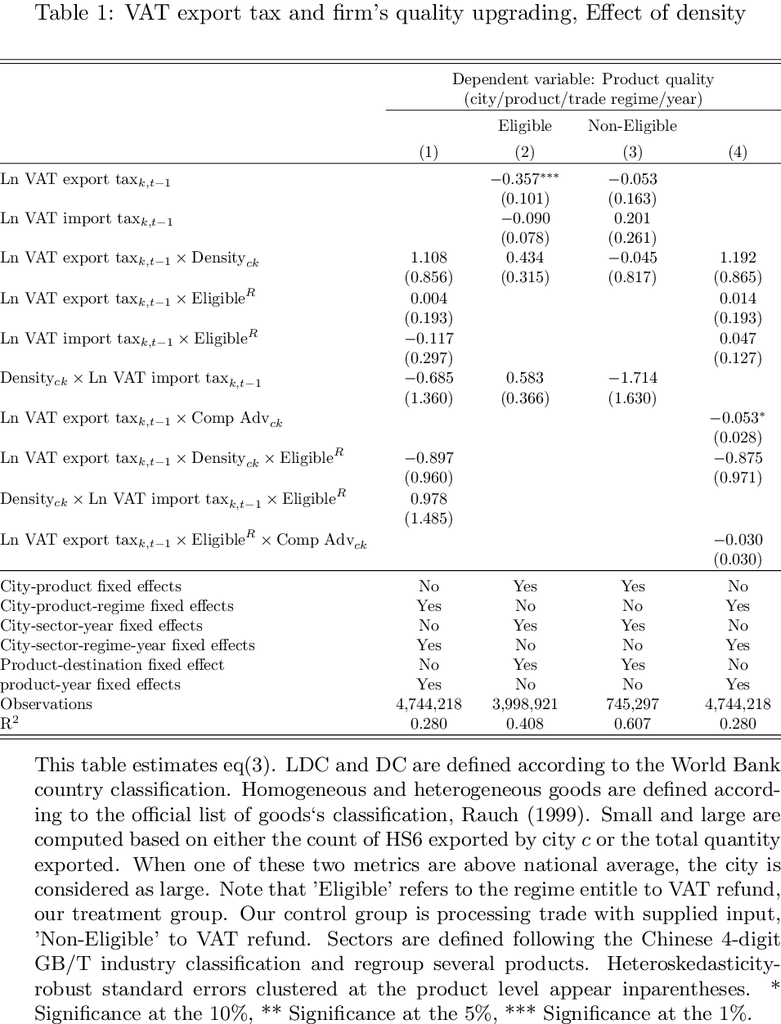

```python
tbe1  = """
This table estimates eq(3).
LDC and DC are defined according to the World Bank country classification.
Homogeneous and heterogeneous goods are defined according to the official list of goods`s classification, Rauch (1999).
Small and large are computed based on either the count of HS6 exported by city $c$ or the total quantity exported.
When one of these two metrics are above national average, the city is considered as large.
Note that 'Eligible' refers to the regime entitle to VAT refund, our treatment group.
Our control group is processing trade with supplied input, 'Non-Eligible' to VAT refund.
Sectors are defined following the Chinese 4-digit GB/T industry
classification and regroup several products.
Heteroskedasticity-robust standard errors
clustered at the product level appear inparentheses.
\sym{*} Significance at the 10\%, \sym{**} Significance at the 5\%, \sym{***} Significance at the 1\%."""

multicolumn ={
    '': 1,
    'Eligible': 1,
    'Non-Eligible': 1,
    '': 1,
}
multi_lines_dep = '(city/product/trade regime/year)'
#new_r = ['& Eligible', 'Non-Eligible', 'All', 'All benchmark']
lb.beautify(table_number = 0,
            #multi_lines_dep = None,
            multi_lines_dep = multi_lines_dep,
            new_row= False,
            multicolumn = multicolumn,
            table_nte = tbe1,
            jupyter_preview = True,
            resolution = 200)
```

## Table 2: Density, no covariate, less constraigning FE

In this table, we split the dataset between `ELIGIBLE` vs `NO ELIGIBLE` with the following fixed effect:

- Column 1 filter `ELIGIBLE` with the main fixed effect:
  - city-product: `fe_ck`
  - city-sector-year: `fe_cst`
  - product-destination: `fe_pj`
- Column 2 filter `ELIGIBLE` with the main fixed effect:
  - city-product: `fe_ck`
  - city-sector-year: `fe_cst`
  - product-year: `fe_kt`
- Column 3 filter `NO ELIGIBLE` with the main fixed effect:
  - city-product: `fe_ck`
  - city-sector-year: `fe_cst`
  - product-destination: `fe_pj`
- Column 4 filter `NO ELIGIBLE` with the main fixed effect:
  - city-product: `fe_ck`
  - city-sector-year: `fe_cst`
  - product-year: `fe_kt`

```python
t_0 <- felm(kandhelwal_quality ~
            ln_lag_tax_rebate * density_china_ville +
            ln_lag_import_tax * density_china_ville
            | fe_ck + fe_cst+fe_pj|0 | hs6, df_final %>% filter(regime == 'ELIGIBLE'),
            exactDOF = TRUE)
t_1 <- felm(kandhelwal_quality ~
            ln_lag_tax_rebate * density_china_ville  +
            ln_lag_import_tax * density_china_ville
            | fe_ck + fe_cst+fe_kt|0 | hs6, df_final %>% filter(regime == 'ELIGIBLE'),
            exactDOF = TRUE)
t_2 <- felm(kandhelwal_quality ~
            ln_lag_tax_rebate * density_china_ville +
            ln_lag_import_tax * density_china_ville
            | fe_ck + fe_cst+fe_pj|0 | hs6, df_final %>% filter(regime != 'ELIGIBLE'),
            exactDOF = TRUE)
t_3 <- felm(kandhelwal_quality ~
            ln_lag_tax_rebate * density_china_ville  +
            ln_lag_import_tax * density_china_ville
            | fe_ck + fe_cst+fe_kt|0 | hs6, df_final %>% filter(regime != 'ELIGIBLE'),
            exactDOF = TRUE)
```

```python
import os
try:
    os.remove("Tables/table_1.txt")
except:
    pass
try:
    os.remove("Tables/table_1.tex")
except:
    pass
try:
    os.remove("Tables/table_1.pdf")
except:
    pass
```

```python
dep <- "Dependent variable: Product quality"
fe1 <- list(
    c("City-product fixed effects", "Yes", "Yes", "Yes", "Yes"),

    c("City-sector-year fixed effects", "Yes", "Yes", "Yes", "Yes"),

    c("Product-destination fixed effect","Yes", "No", "Yes", "No"),

    c("product-year fixed effects", "No", "Yes", "No", "Yes")
             )

table_1 <- go_latex(list(
    t_0,t_1, t_2, t_3
),
    title="VAT export tax and firm’s quality upgrading, Effect of density",
    dep_var = dep,
    addFE=fe1,
    save=TRUE,
    note = FALSE,
    name="Tables/table_1.txt"
)
```

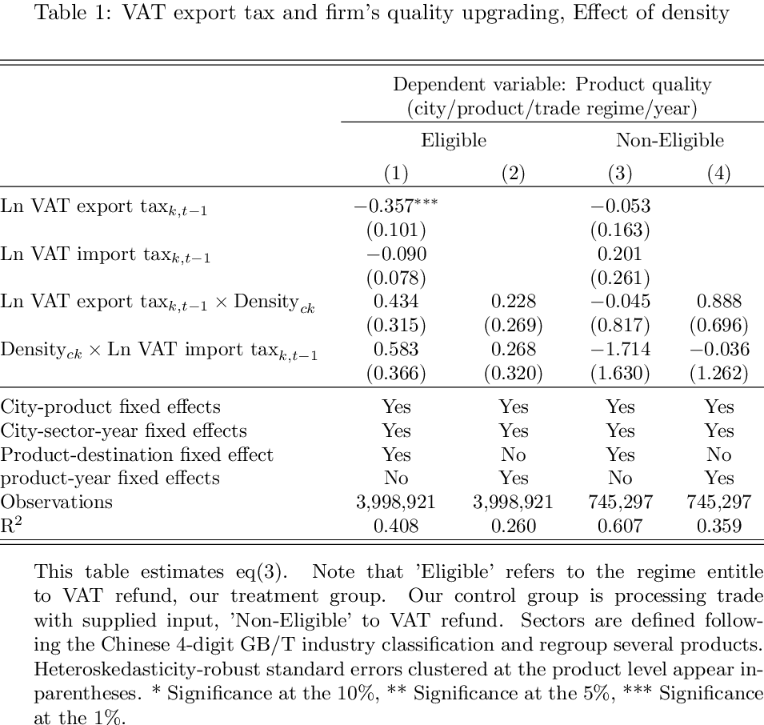

```python
tbe1  = """
This table estimates eq(3).
Note that 'Eligible' refers to the regime entitle to VAT refund, our treatment group.
Our control group is processing trade with supplied input, 'Non-Eligible' to VAT refund.
Sectors are defined following the Chinese 4-digit GB/T industry
classification and regroup several products.
Heteroskedasticity-robust standard errors
clustered at the product level appear inparentheses.
\sym{*} Significance at the 10\%, \sym{**} Significance at the 5\%, \sym{***} Significance at the 1\%."""

multicolumn ={
    'Eligible': 2,
    'Non-Eligible': 2,
}
multi_lines_dep = '(city/product/trade regime/year)'
#new_r = ['& Eligible', 'Non-Eligible', 'All', 'All benchmark']
lb.beautify(table_number = 1,
            #multi_lines_dep = None,
            multi_lines_dep = multi_lines_dep,
            new_row= False,
            multicolumn = multicolumn,
            reorder_var = None,
            table_nte = tbe1,
            jupyter_preview = True,
            resolution = 200)
```

## Table 3: Density, no covariate, less constraigning FE

- Column 1 with the main fixed effect:
  - city-product: `fe_ck`
  - city-sector-year: `fe_cst`
  - product-destination: `fe_pj`
- Column 2 with the main fixed effect:
  - city-product-regime: `fe_ckr`
  - city-sector-year: `fe_cst`
  - product-destination: `fe_pj`
- Column 3 with the main fixed effect:
  - city-product-regime: `fe_ckr`
  - city-sector-year: `fe_cst`
  - product-year: `fe_kt`
- Column 4 with the main fixed effect, with RCA:
  - city-product: `fe_ck`
  - city-sector-year: `fe_cst`
  - product-destination: `fe_pj`
- Column 5 with the main fixed effect, with RCA:
  - city-product-regime: `fe_ckr`
  - city-sector-year: `fe_cst`
  - product-destination: `fe_pj`
- Column 6 with the main fixed effect, with RCA:
  - city-product-regime: `fe_ckr`
  - city-sector-year: `fe_cst`
  - product-year: `fe_kt`

```python
t_0 <- felm(kandhelwal_quality ~
            ln_lag_tax_rebate * density_china_ville * regime +
            ln_lag_import_tax * density_china_ville * regime
            | fe_ck + fe_cst+fe_pj|0 | hs6, df_final,
            exactDOF = TRUE)
t_0 <- change_import_tax_order(t_0)
t_1 <- felm(kandhelwal_quality ~
            ln_lag_tax_rebate * density_china_ville * regime +
            ln_lag_import_tax * density_china_ville * regime
            | fe_ckr + fe_cst+fe_pj|0 | hs6, df_final,
            exactDOF = TRUE)
t_1 <- change_import_tax_order(t_1)
t_2 <- felm(kandhelwal_quality ~
            ln_lag_tax_rebate * density_china_ville * regime +
            ln_lag_import_tax * density_china_ville * regime
            | fe_ckr + fe_cst+fe_kt|0 | hs6, df_final,
            exactDOF = TRUE)
t_2 <- change_import_tax_order(t_2)
t_3 <- felm(kandhelwal_quality ~
            ln_lag_tax_rebate * density_china_ville * regime +
            ln_lag_import_tax * density_china_ville * regime +
            ln_lag_tax_rebate * balassa * regime
            | fe_ck + fe_cst+fe_pj|0 | hs6, df_final,
            exactDOF = TRUE)
t_3 <- change_import_tax_order(t_3)
t_4 <- felm(kandhelwal_quality ~
            ln_lag_tax_rebate * density_china_ville * regime +
            ln_lag_import_tax * density_china_ville * regime +
            ln_lag_tax_rebate * balassa * regime
            | fe_ckr + fe_cst+fe_pj|0 | hs6, df_final,
            exactDOF = TRUE)
t_4 <- change_import_tax_order(t_4)
t_5 <- felm(kandhelwal_quality ~
            ln_lag_tax_rebate * density_china_ville * regime +
            ln_lag_import_tax * density_china_ville * regime +
            ln_lag_tax_rebate * balassa * regime
            | fe_ckr + fe_cst+fe_kt|0 | hs6, df_final,
            exactDOF = TRUE)
t_5 <- change_import_tax_order(t_5)
```

```python
import os
try:
    os.remove("Tables/table_2.txt")
except:
    pass
try:
    os.remove("Tables/table_2.tex")
except:
    pass
try:
    os.remove("Tables/table_2.pdf")
except:
    pass
```

```python
dep <- "Dependent variable: Product quality"
fe1 <- list(
    c("City-product fixed effects", "Yes", "Yes", "No", "Yes", "Yes", "No"),

    c("City-product-regime fixed effects", "No", "Yes", "Yes", "No", "Yes", "Yes"),

    c("City-sector-year fixed effects", "Yes", "Yes", "Yes", "Yes", "Yes", "Yes"),

    c("Product-destination fixed effect","Yes", "Yes", "No", "Yes", "Yes", "No"),

    c("product-year fixed effects", "No", "No", "Yes", "No", "No", "Yes")
             )

table_1 <- go_latex(list(
    t_0,t_1, t_2, t_3, t_4, t_5
),
    title="VAT export tax and firm’s quality upgrading, Effect of density",
    dep_var = dep,
    addFE=fe1,
    save=TRUE,
    note = FALSE,
    name="Tables/table_2.txt"
)
```

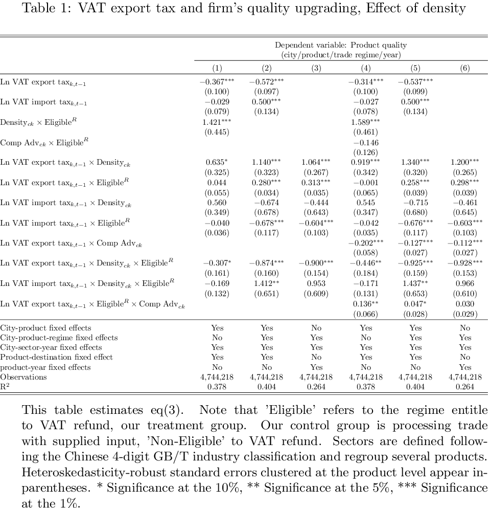

```python
reorder = {
    # Old, New
    4:2, ## Density * eligible
    8:3, ## comp * eligibile
}

tbe1  = """
This table estimates eq(3).
Note that 'Eligible' refers to the regime entitle to VAT refund, our treatment group.
Our control group is processing trade with supplied input, 'Non-Eligible' to VAT refund.
Sectors are defined following the Chinese 4-digit GB/T industry
classification and regroup several products.
Heteroskedasticity-robust standard errors
clustered at the product level appear inparentheses.
\sym{*} Significance at the 10\%, \sym{**} Significance at the 5\%, \sym{***} Significance at the 1\%."""

multicolumn ={
    '': 1,
    'Eligible': 1,
    'Non-Eligible': 1,
    '': 1,
}
multi_lines_dep = '(city/product/trade regime/year)'
#new_r = ['& Eligible', 'Non-Eligible', 'All', 'All benchmark']
lb.beautify(table_number = 2,
            #multi_lines_dep = None,
            multi_lines_dep = multi_lines_dep,
            new_row= False,
            multicolumn = None,
            reorder_var = reorder,
            table_nte = tbe1,
            jupyter_preview = True,
            resolution = 200)
```

## Table 4: Density, with covariates city, regime destination, product

- Column 1 is the baseline column with the main fixed effect:
  - city-product-regime: `fe_ckr`
  - city-sector-regime-year: `fe_csrt`
  - product-year: `fe_kt`
- Columns 2 and 3 split the dataset into Eligible and Non eligible. Fixed effect are :
  - city-product: `fe_ck`
  - city-sector-year: `fe_cst`
  - product-destination: `fe_pj`
- Column 4 include Comparative advantages with the main fixed effect:
  - city-product-regime: `fe_ckr`
  - city-sector-regime-year: `fe_csrt`
  - product-year: `fe_kt`

Sector is defined as the GBT 4 digits

```python
#### COUNTRIES
t_0 <- felm(kandhelwal_quality ~
            ln_lag_tax_rebate * density_china_ville * regime +
            ln_lag_import_tax * ln_lag_import_tax * regime +
            lag_foreign_export_share_ckjr + lag_soe_export_share_ckjr
            | fe_ckr + fe_csrt+fe_kt|0 | hs6, df_final,
            exactDOF = TRUE)

t_1 <- felm(kandhelwal_quality ~
            ln_lag_tax_rebate * density_china_ville  +
            ln_lag_import_tax * density_china_ville +
            lag_foreign_export_share_ckjr + lag_soe_export_share_ckjr
            | fe_ck + fe_cst+fe_pj |0 | hs6, df_final %>% filter(regime == 'ELIGIBLE'),
            exactDOF = TRUE)

#### GOODS
t_2 <- felm(kandhelwal_quality ~
            ln_lag_tax_rebate * density_china_ville  +
            ln_lag_import_tax * density_china_ville +
            lag_foreign_export_share_ckjr + lag_soe_export_share_ckjr
            | fe_ck + fe_cst+fe_pj |0 | hs6, df_final %>% filter(regime != 'ELIGIBLE'),
            exactDOF = TRUE)

t_3 <- felm(kandhelwal_quality ~
            ln_lag_tax_rebate * density_china_ville * regime +
            ln_lag_import_tax * ln_lag_import_tax * regime +
            ln_lag_tax_rebate* balassa * regime +
            lag_foreign_export_share_ckjr + lag_soe_export_share_ckjr
            | fe_ckr + fe_csrt+fe_kt|0 | hs6, df_final,
            exactDOF = TRUE)
```

```python
import os
try:
    os.remove("Tables/table_3.txt")
except:
    pass
try:
    os.remove("Tables/table_3.tex")
except:
    pass
try:
    os.remove("Tables/table_3.pdf")
except:
    pass
```

```python
dep <- "Dependent variable: Product quality"
fe1 <- list(
    c("City-product fixed effects", "No", "Yes", "Yes", "No"),

    c("City-product-regime fixed effects", "Yes", "No", "No", "Yes"),

    c("City-sector-year fixed effects", "No", "Yes", "Yes", "No"),

    c("City-sector-regime-year fixed effects", "Yes", "No", "No", "Yes"),

    c("Product-destination fixed effect","No", "Yes", "Yes", "No"),

    c("product-year fixed effects", "Yes", "No", "No", "Yes")
             )

table_1 <- go_latex(list(
    t_0,t_1, t_2, t_3
),
    title="VAT export tax and firm’s quality upgrading, Effect of density",
    dep_var = dep,
    addFE=fe1,
    save=TRUE,
    note = FALSE,
    name="Tables/table_3.txt"
)
```

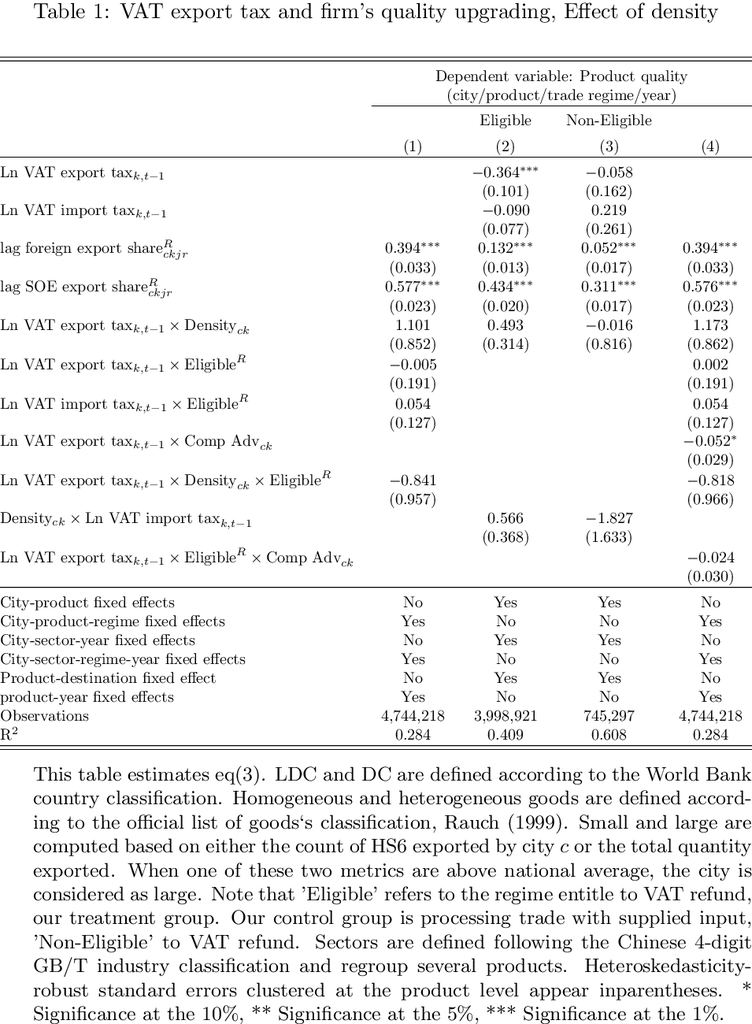

```python
tbe1  = """
This table estimates eq(3).
LDC and DC are defined according to the World Bank country classification.
Homogeneous and heterogeneous goods are defined according to the official list of goods`s classification, Rauch (1999).
Small and large are computed based on either the count of HS6 exported by city $c$ or the total quantity exported.
When one of these two metrics are above national average, the city is considered as large.
Note that 'Eligible' refers to the regime entitle to VAT refund, our treatment group.
Our control group is processing trade with supplied input, 'Non-Eligible' to VAT refund.
Sectors are defined following the Chinese 4-digit GB/T industry
classification and regroup several products.
Heteroskedasticity-robust standard errors
clustered at the product level appear inparentheses.
\sym{*} Significance at the 10\%, \sym{**} Significance at the 5\%, \sym{***} Significance at the 1\%."""

multicolumn ={
    '': 1,
    'Eligible': 1,
    'Non-Eligible': 1,
    '': 1,
}
multi_lines_dep = '(city/product/trade regime/year)'
#new_r = ['& Eligible', 'Non-Eligible', 'All', 'All benchmark']
lb.beautify(table_number = 3,
            #multi_lines_dep = None,
            multi_lines_dep = multi_lines_dep,
            new_row= False,
            multicolumn = multicolumn,
            table_nte = tbe1,
            jupyter_preview = True,
            resolution = 200)
```

## Table 5: Density, with covariates city, regime destination, product, less constraigning FE

In this table, we split the dataset between `ELIGIBLE` vs `NO ELIGIBLE` with the following fixed effect:

- Column 1 filter `ELIGIBLE` with the main fixed effect:
  - city-product: `fe_ck`
  - city-sector-year: `fe_cst`
  - product-destination: `fe_pj`
- Column 2 filter `ELIGIBLE` with the main fixed effect:
  - city-product: `fe_ck`
  - city-sector-year: `fe_cst`
  - product-year: `fe_kt`
- Column 3 filter `NO ELIGIBLE` with the main fixed effect:
  - city-product: `fe_ck`
  - city-sector-year: `fe_cst`
  - product-destination: `fe_pj`
- Column 4 filter `NO ELIGIBLE` with the main fixed effect:
  - city-product: `fe_ck`
  - city-sector-year: `fe_cst`
  - product-year: `fe_kt`

```python
t_0 <- felm(kandhelwal_quality ~
            ln_lag_tax_rebate * density_china_ville +
            ln_lag_import_tax * density_china_ville +
            lag_foreign_export_share_ckjr + lag_soe_export_share_ckjr
            | fe_ck + fe_cst+fe_pj|0 | hs6, df_final %>% filter(regime == 'ELIGIBLE'),
            exactDOF = TRUE)
t_1 <- felm(kandhelwal_quality ~
            ln_lag_tax_rebate * density_china_ville  +
            ln_lag_import_tax * density_china_ville +
            lag_foreign_export_share_ckjr + lag_soe_export_share_ckjr
            | fe_ck + fe_cst+fe_kt|0 | hs6, df_final %>% filter(regime == 'ELIGIBLE'),
            exactDOF = TRUE)
t_2 <- felm(kandhelwal_quality ~
            ln_lag_tax_rebate * density_china_ville +
            ln_lag_import_tax * density_china_ville +
            lag_foreign_export_share_ckjr + lag_soe_export_share_ckjr
            | fe_ck + fe_cst+fe_pj|0 | hs6, df_final %>% filter(regime != 'ELIGIBLE'),
            exactDOF = TRUE)
t_3 <- felm(kandhelwal_quality ~
            ln_lag_tax_rebate * density_china_ville  +
            ln_lag_import_tax * density_china_ville +
            lag_foreign_export_share_ckjr + lag_soe_export_share_ckjr
            | fe_ck + fe_cst+fe_kt|0 | hs6, df_final %>% filter(regime != 'ELIGIBLE'),
            exactDOF = TRUE)
```

```python
import os
try:
    os.remove("Tables/table_4.txt")
except:
    pass
try:
    os.remove("Tables/table_4.tex")
except:
    pass
try:
    os.remove("Tables/table_4.pdf")
except:
    pass
```

```python
dep <- "Dependent variable: Product quality"
fe1 <- list(
    c("City-product fixed effects", "Yes", "Yes", "Yes", "Yes"),

    c("City-sector-year fixed effects", "Yes", "Yes", "Yes", "Yes"),

    c("Product-destination fixed effect","Yes", "No", "Yes", "No"),

    c("product-year fixed effects", "No", "Yes", "No", "Yes")
             )

table_1 <- go_latex(list(
    t_0,t_1, t_2, t_3
),
    title="VAT export tax and firm’s quality upgrading, Effect of density",
    dep_var = dep,
    addFE=fe1,
    save=TRUE,
    note = FALSE,
    name="Tables/table_4.txt"
)
```

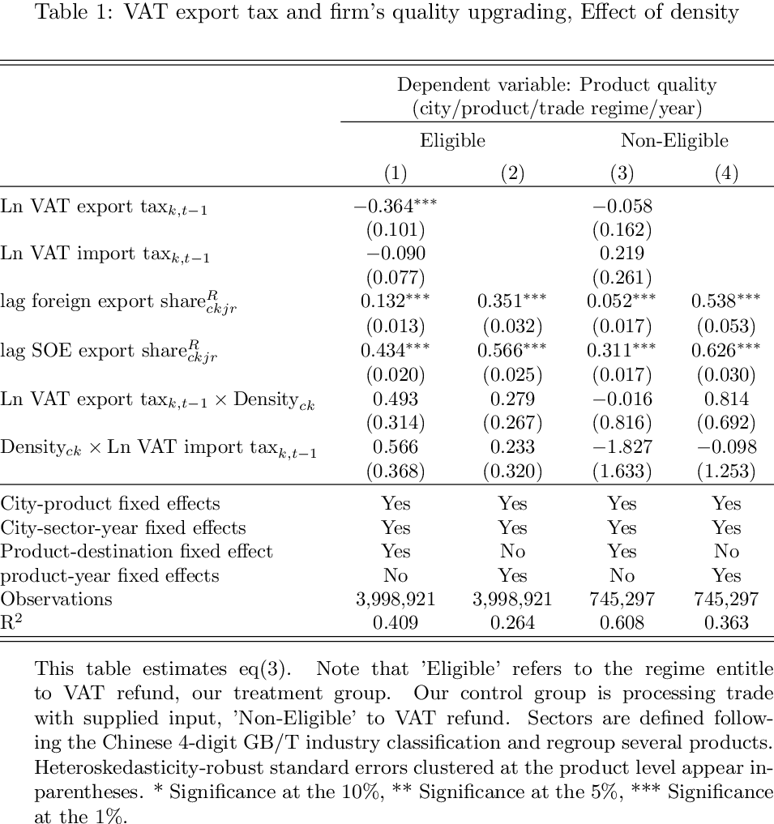

```python
tbe1  = """
This table estimates eq(3).
Note that 'Eligible' refers to the regime entitle to VAT refund, our treatment group.
Our control group is processing trade with supplied input, 'Non-Eligible' to VAT refund.
Sectors are defined following the Chinese 4-digit GB/T industry
classification and regroup several products.
Heteroskedasticity-robust standard errors
clustered at the product level appear inparentheses.
\sym{*} Significance at the 10\%, \sym{**} Significance at the 5\%, \sym{***} Significance at the 1\%."""

multicolumn ={
    'Eligible': 2,
    'Non-Eligible': 2,
}
multi_lines_dep = '(city/product/trade regime/year)'
#new_r = ['& Eligible', 'Non-Eligible', 'All', 'All benchmark']
lb.beautify(table_number = 4,
            #multi_lines_dep = None,
            multi_lines_dep = multi_lines_dep,
            new_row= False,
            multicolumn = multicolumn,
            reorder_var = None,
            table_nte = tbe1,
            jupyter_preview = True,
            resolution = 200)
```

## Table 6: Density, with covariates city, regime destination, product, less constraigning FE

- Column 1 with the main fixed effect:
  - city-product: `fe_ck`
  - city-sector-year: `fe_cst`
  - product-destination: `fe_pj`
- Column 2 with the main fixed effect:
  - city-product-regime: `fe_ckr`
  - city-sector-year: `fe_cst`
  - product-destination: `fe_pj`
- Column 3 with the main fixed effect:
  - city-product-regime: `fe_ckr`
  - city-sector-year: `fe_cst`
  - product-year: `fe_kt`
- Column 4 with the main fixed effect, with RCA:
  - city-product: `fe_ck`
  - city-sector-year: `fe_cst`
  - product-destination: `fe_pj`
- Column 5 with the main fixed effect, with RCA:
  - city-product-regime: `fe_ckr`
  - city-sector-year: `fe_cst`
  - product-destination: `fe_pj`
- Column 6 with the main fixed effect, with RCA:
  - city-product-regime: `fe_ckr`
  - city-sector-year: `fe_cst`
  - product-year: `fe_kt`

```python
t_0 <- felm(kandhelwal_quality ~
            ln_lag_tax_rebate * density_china_ville * regime +
            ln_lag_import_tax * density_china_ville * regime +
            lag_foreign_export_share_ckjr + lag_soe_export_share_ckjr
            | fe_ck + fe_cst+fe_pj|0 | hs6, df_final,
            exactDOF = TRUE)
t_0 <- change_import_tax_order(t_0)
t_1 <- felm(kandhelwal_quality ~
            ln_lag_tax_rebate * density_china_ville * regime +
            ln_lag_import_tax * density_china_ville * regime +
            lag_foreign_export_share_ckjr + lag_soe_export_share_ckjr
            | fe_ckr + fe_cst+fe_pj|0 | hs6, df_final,
            exactDOF = TRUE)
t_1 <- change_import_tax_order(t_1)
t_2 <- felm(kandhelwal_quality ~
            ln_lag_tax_rebate * density_china_ville * regime +
            ln_lag_import_tax * density_china_ville * regime +
            lag_foreign_export_share_ckjr + lag_soe_export_share_ckjr
            | fe_ckr + fe_cst+fe_kt|0 | hs6, df_final,
            exactDOF = TRUE)
t_2 <- change_import_tax_order(t_2)
t_3 <- felm(kandhelwal_quality ~
            ln_lag_tax_rebate * density_china_ville * regime +
            ln_lag_import_tax * density_china_ville * regime +
            ln_lag_tax_rebate * balassa * regime +
            lag_foreign_export_share_ckjr + lag_soe_export_share_ckjr
            | fe_ck + fe_cst+fe_pj|0 | hs6, df_final,
            exactDOF = TRUE)
t_3 <- change_import_tax_order(t_3)
t_4 <- felm(kandhelwal_quality ~
            ln_lag_tax_rebate * density_china_ville * regime +
            ln_lag_import_tax * density_china_ville * regime +
            ln_lag_tax_rebate * balassa * regime +
            lag_foreign_export_share_ckjr + lag_soe_export_share_ckjr
            | fe_ckr + fe_cst+fe_pj|0 | hs6, df_final,
            exactDOF = TRUE)
t_4 <- change_import_tax_order(t_4)
t_5 <- felm(kandhelwal_quality ~
            ln_lag_tax_rebate * density_china_ville * regime +
            ln_lag_import_tax * density_china_ville * regime +
            ln_lag_tax_rebate * balassa * regime +
            lag_foreign_export_share_ckjr + lag_soe_export_share_ckjr
            | fe_ckr + fe_cst+fe_kt|0 | hs6, df_final,
            exactDOF = TRUE)
t_5 <- change_import_tax_order(t_5)
```

```python
import os
try:
    os.remove("Tables/table_5.txt")
except:
    pass
try:
    os.remove("Tables/table_5.tex")
except:
    pass
try:
    os.remove("Tables/table_5.pdf")
except:
    pass
```

```python
dep <- "Dependent variable: Product quality"
fe1 <- list(
    c("City-product fixed effects", "Yes", "Yes", "No", "Yes", "Yes", "No"),

    c("City-product-regime fixed effects", "No", "Yes", "Yes", "No", "Yes", "Yes"),

    c("City-sector-year fixed effects", "Yes", "Yes", "Yes", "Yes", "Yes", "Yes"),

    c("Product-destination fixed effect","Yes", "Yes", "No", "Yes", "Yes", "No"),

    c("product-year fixed effects", "No", "No", "Yes", "No", "No", "Yes")
             )

table_1 <- go_latex(list(
    t_0,t_1, t_2, t_3, t_4, t_5
),
    title="VAT export tax and firm’s quality upgrading, Effect of density",
    dep_var = dep,
    addFE=fe1,
    save=TRUE,
    note = FALSE,
    name="Tables/table_5.txt"
)
```

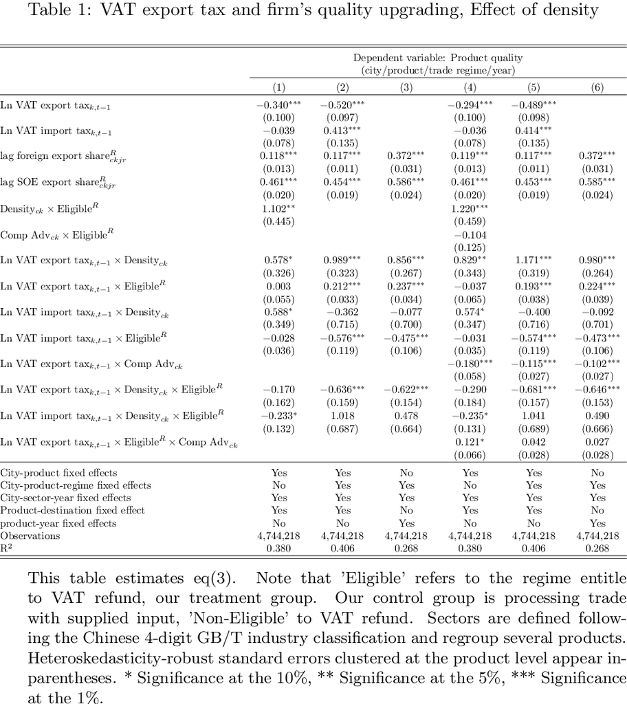

```python
reorder = {
    # Old, New
    6:4, ## Density * eligible
    10:5, ## comp * eligibile
}

tbe1  = """
This table estimates eq(3).
Note that 'Eligible' refers to the regime entitle to VAT refund, our treatment group.
Our control group is processing trade with supplied input, 'Non-Eligible' to VAT refund.
Sectors are defined following the Chinese 4-digit GB/T industry
classification and regroup several products.
Heteroskedasticity-robust standard errors
clustered at the product level appear inparentheses.
\sym{*} Significance at the 10\%, \sym{**} Significance at the 5\%, \sym{***} Significance at the 1\%."""

multicolumn ={
    '': 1,
    'Eligible': 1,
    'Non-Eligible': 1,
    '': 1,
}
multi_lines_dep = '(city/product/trade regime/year)'
#new_r = ['& Eligible', 'Non-Eligible', 'All', 'All benchmark']
lb.beautify(table_number = 5,
            #multi_lines_dep = None,
            multi_lines_dep = multi_lines_dep,
            new_row= False,
            multicolumn = None,
            reorder_var = reorder,
            table_nte = tbe1,
            jupyter_preview = True,
            resolution = 200)
```

## Table 7: Density, with covariates city, regime, product

- Column 1 is the baseline column with the main fixed effect:
  - city-product-regime: `fe_ckr`
  - city-sector-regime-year: `fe_csrt`
  - product-year: `fe_kt`
- Columns 2 and 3 split the dataset into Eligible and Non eligible. Fixed effect are :
  - city-product: `fe_ck`
  - city-sector-year: `fe_cst`
  - product-destination: `fe_pj`
- Column 4 include Comparative advantages with the main fixed effect:
  - city-product-regime: `fe_ckr`
  - city-sector-regime-year: `fe_csrt`
  - product-year: `fe_kt`

Sector is defined as the GBT 4 digits

```python
#### COUNTRIES
t_0 <- felm(kandhelwal_quality ~
            ln_lag_tax_rebate * density_china_ville * regime +
            ln_lag_import_tax * regime * ln_lag_import_tax +
            lag_foreign_export_share_ckr + lag_soe_export_share_ckr
            | fe_ckr + fe_csrt+fe_kt|0 | hs6, df_final,
            exactDOF = TRUE)

t_1 <- felm(kandhelwal_quality ~
            ln_lag_tax_rebate * density_china_ville  +
            ln_lag_import_tax * density_china_ville +
            lag_foreign_export_share_ckr + lag_soe_export_share_ckr
            | fe_ck + fe_cst+fe_pj |0 | hs6, df_final %>% filter(regime == 'ELIGIBLE'),
            exactDOF = TRUE)

#### GOODS
t_2 <- felm(kandhelwal_quality ~
            ln_lag_tax_rebate * density_china_ville  +
            ln_lag_import_tax * density_china_ville +
            lag_foreign_export_share_ckr + lag_soe_export_share_ckr
            | fe_ck + fe_cst+fe_pj |0 | hs6, df_final %>% filter(regime != 'ELIGIBLE'),
            exactDOF = TRUE)

t_3 <- felm(kandhelwal_quality ~
            ln_lag_tax_rebate * density_china_ville * regime +
            ln_lag_import_tax * regime * ln_lag_import_tax +
            ln_lag_tax_rebate* balassa * regime +
            lag_foreign_export_share_ckr + lag_soe_export_share_ckr
            | fe_ckr + fe_csrt+fe_kt|0 | hs6, df_final,
            exactDOF = TRUE)
```

```python
import os
try:
    os.remove("Tables/table_6.txt")
except:
    pass
try:
    os.remove("Tables/table_7.tex")
except:
    pass
try:
    os.remove("Tables/table_6.pdf")
except:
    pass
```

```python
dep <- "Dependent variable: Product quality"
fe1 <- list(
    c("City-product fixed effects", "No", "Yes", "Yes", "No"),

    c("City-product-regime fixed effects", "Yes", "No", "No", "Yes"),

    c("City-sector-year fixed effects", "No", "Yes", "Yes", "No"),

    c("City-sector-regime-year fixed effects", "Yes", "No", "No", "Yes"),

    c("Product-destination fixed effect","No", "Yes", "Yes", "No"),

    c("product-year fixed effects", "Yes", "No", "No", "Yes")
             )

table_1 <- go_latex(list(
    t_0,t_1, t_2, t_3
),
    title="VAT export tax and firm’s quality upgrading, Effect of density",
    dep_var = dep,
    addFE=fe1,
    save=TRUE,
    note = FALSE,
    name="Tables/table_6.txt"
)
```

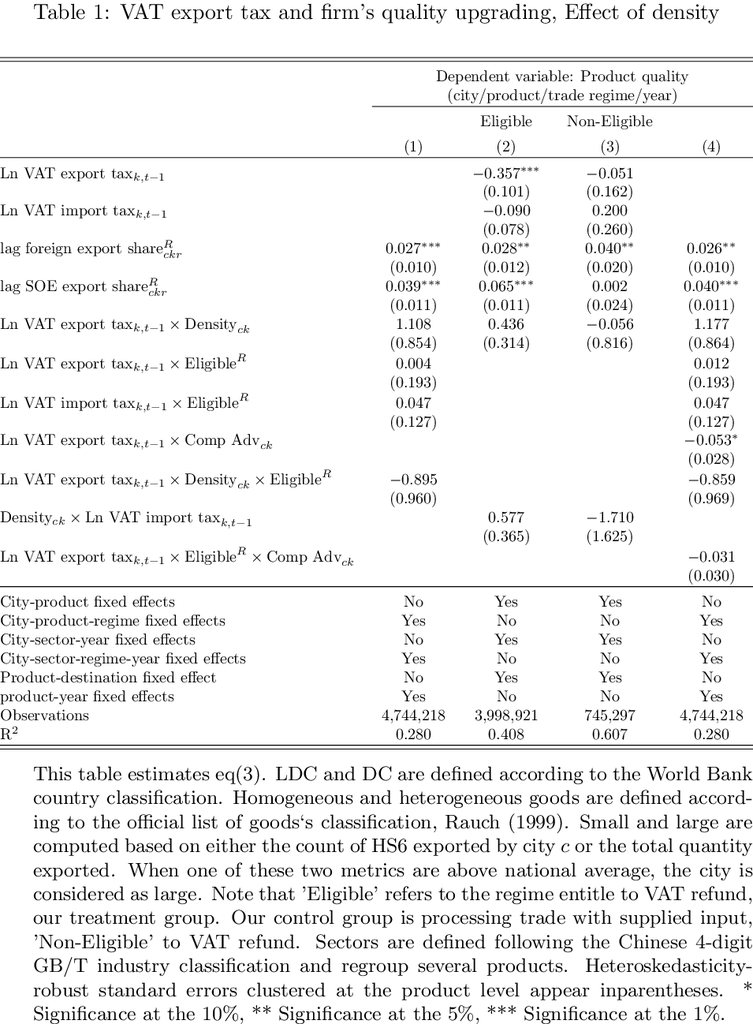

```python
tbe1  = """
This table estimates eq(3).
LDC and DC are defined according to the World Bank country classification.
Homogeneous and heterogeneous goods are defined according to the official list of goods`s classification, Rauch (1999).
Small and large are computed based on either the count of HS6 exported by city $c$ or the total quantity exported.
When one of these two metrics are above national average, the city is considered as large.
Note that 'Eligible' refers to the regime entitle to VAT refund, our treatment group.
Our control group is processing trade with supplied input, 'Non-Eligible' to VAT refund.
Sectors are defined following the Chinese 4-digit GB/T industry
classification and regroup several products.
Heteroskedasticity-robust standard errors
clustered at the product level appear inparentheses.
\sym{*} Significance at the 10\%, \sym{**} Significance at the 5\%, \sym{***} Significance at the 1\%."""

multicolumn ={
    '': 1,
    'Eligible': 1,
    'Non-Eligible': 1,
    '': 1,
}
multi_lines_dep = '(city/product/trade regime/year)'
#new_r = ['& Eligible', 'Non-Eligible', 'All', 'All benchmark']
lb.beautify(table_number = 6,
            #multi_lines_dep = None,
            multi_lines_dep = multi_lines_dep,
            new_row= False,
            multicolumn = multicolumn,
            table_nte = tbe1,
            jupyter_preview = True,
            resolution = 200)
```

## Table 8: Density, with covariates city, regime, product, less constraigning FE

In this table, we split the dataset between `ELIGIBLE` vs `NO ELIGIBLE` with the following fixed effect:

- Column 1 filter `ELIGIBLE` with the main fixed effect:
  - city-product: `fe_ck`
  - city-sector-year: `fe_cst`
  - product-destination: `fe_pj`
- Column 2 filter `ELIGIBLE` with the main fixed effect:
  - city-product: `fe_ck`
  - city-sector-year: `fe_cst`
  - product-year: `fe_kt`
- Column 3 filter `NO ELIGIBLE` with the main fixed effect:
  - city-product: `fe_ck`
  - city-sector-year: `fe_cst`
  - product-destination: `fe_pj`
- Column 4 filter `NO ELIGIBLE` with the main fixed effect:
  - city-product: `fe_ck`
  - city-sector-year: `fe_cst`
  - product-year: `fe_kt`

```python
t_0 <- felm(kandhelwal_quality ~
            ln_lag_tax_rebate * density_china_ville +
            ln_lag_import_tax * density_china_ville +
            lag_foreign_export_share_ckr + lag_soe_export_share_ckr
            | fe_ck + fe_cst+fe_pj|0 | hs6, df_final %>% filter(regime == 'ELIGIBLE'),
            exactDOF = TRUE)
t_1 <- felm(kandhelwal_quality ~
            ln_lag_tax_rebate * density_china_ville  +
            ln_lag_import_tax * density_china_ville  +
            lag_foreign_export_share_ckr + lag_soe_export_share_ckr
            | fe_ck + fe_cst+fe_kt|0 | hs6, df_final %>% filter(regime == 'ELIGIBLE'),
            exactDOF = TRUE)
t_2 <- felm(kandhelwal_quality ~
            ln_lag_tax_rebate * density_china_ville +
            ln_lag_import_tax * density_china_ville +
            lag_foreign_export_share_ckr + lag_soe_export_share_ckr
            | fe_ck + fe_cst+fe_pj|0 | hs6, df_final %>% filter(regime != 'ELIGIBLE'),
            exactDOF = TRUE)
t_3 <- felm(kandhelwal_quality ~
            ln_lag_tax_rebate * density_china_ville  +
            ln_lag_import_tax * density_china_ville +
            lag_foreign_export_share_ckr + lag_soe_export_share_ckr
            | fe_ck + fe_cst+fe_kt|0 | hs6, df_final %>% filter(regime != 'ELIGIBLE'),
            exactDOF = TRUE)
```

```python
import os
try:
    os.remove("Tables/table_7.txt")
except:
    pass
try:
    os.remove("Tables/table_7.tex")
except:
    pass
try:
    os.remove("Tables/table_7.pdf")
except:
    pass
```

```python
dep <- "Dependent variable: Product quality"
fe1 <- list(
    c("City-product fixed effects", "Yes", "Yes", "Yes", "Yes"),

    c("City-sector-year fixed effects", "Yes", "Yes", "Yes", "Yes"),

    c("Product-destination fixed effect","Yes", "No", "Yes", "No"),

    c("product-year fixed effects", "No", "Yes", "No", "Yes")
             )

table_1 <- go_latex(list(
    t_0,t_1, t_2, t_3
),
    title="VAT export tax and firm’s quality upgrading, Effect of density",
    dep_var = dep,
    addFE=fe1,
    save=TRUE,
    note = FALSE,
    name="Tables/table_7.txt"
)
```

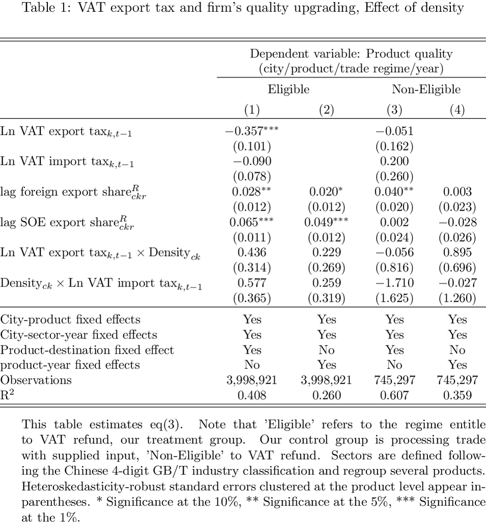

```python
tbe1  = """
This table estimates eq(3).
Note that 'Eligible' refers to the regime entitle to VAT refund, our treatment group.
Our control group is processing trade with supplied input, 'Non-Eligible' to VAT refund.
Sectors are defined following the Chinese 4-digit GB/T industry
classification and regroup several products.
Heteroskedasticity-robust standard errors
clustered at the product level appear inparentheses.
\sym{*} Significance at the 10\%, \sym{**} Significance at the 5\%, \sym{***} Significance at the 1\%."""

multicolumn ={
    'Eligible': 2,
    'Non-Eligible': 2,
}
multi_lines_dep = '(city/product/trade regime/year)'
#new_r = ['& Eligible', 'Non-Eligible', 'All', 'All benchmark']
lb.beautify(table_number = 7,
            #multi_lines_dep = None,
            multi_lines_dep = multi_lines_dep,
            new_row= False,
            multicolumn = multicolumn,
            reorder_var = None,
            table_nte = tbe1,
            jupyter_preview = True,
            resolution = 200)
```

## Table 9: Density, with covariates city, regime, product, less constraigning FE

- Column 1 with the main fixed effect:
  - city-product: `fe_ck`
  - city-sector-year: `fe_cst`
  - product-destination: `fe_pj`
- Column 2 with the main fixed effect:
  - city-product-regime: `fe_ckr`
  - city-sector-year: `fe_cst`
  - product-destination: `fe_pj`
- Column 3 with the main fixed effect:
  - city-product-regime: `fe_ckr`
  - city-sector-year: `fe_cst`
  - product-year: `fe_kt`
- Column 4 with the main fixed effect, with RCA:
  - city-product: `fe_ck`
  - city-sector-year: `fe_cst`
  - product-destination: `fe_pj`
- Column 5 with the main fixed effect, with RCA:
  - city-product-regime: `fe_ckr`
  - city-sector-year: `fe_cst`
  - product-destination: `fe_pj`
- Column 6 with the main fixed effect, with RCA:
  - city-product-regime: `fe_ckr`
  - city-sector-year: `fe_cst`
  - product-year: `fe_kt`

```python
t_0 <- felm(kandhelwal_quality ~
            ln_lag_tax_rebate * density_china_ville * regime +
            ln_lag_import_tax * density_china_ville * regime +
            lag_foreign_export_share_ckr + lag_soe_export_share_ckr
            | fe_ck + fe_cst+fe_pj|0 | hs6, df_final,
            exactDOF = TRUE)
t_0 <- change_import_tax_order(t_0)
t_1 <- felm(kandhelwal_quality ~
            ln_lag_tax_rebate * density_china_ville * regime +
            ln_lag_import_tax * density_china_ville * regime +
            lag_foreign_export_share_ckr + lag_soe_export_share_ckr
            | fe_ckr + fe_cst+fe_pj|0 | hs6, df_final,
            exactDOF = TRUE)
t_1 <- change_import_tax_order(t_1)
t_2 <- felm(kandhelwal_quality ~
            ln_lag_tax_rebate * density_china_ville * regime +
            ln_lag_import_tax * density_china_ville * regime +
            lag_foreign_export_share_ckr + lag_soe_export_share_ckr
            | fe_ckr + fe_cst+fe_kt|0 | hs6, df_final,
            exactDOF = TRUE)
t_2 <- change_import_tax_order(t_2)
t_3 <- felm(kandhelwal_quality ~
            ln_lag_tax_rebate * density_china_ville * regime +
            ln_lag_import_tax * density_china_ville * regime +
            ln_lag_tax_rebate * balassa * regime  +
            lag_foreign_export_share_ckr + lag_soe_export_share_ckr
            | fe_ck + fe_cst+fe_pj|0 | hs6, df_final,
            exactDOF = TRUE)
t_3 <- change_import_tax_order(t_3)
t_4 <- felm(kandhelwal_quality ~
            ln_lag_tax_rebate * density_china_ville * regime +
            ln_lag_import_tax * density_china_ville * regime +
            ln_lag_tax_rebate * balassa * regime +
            lag_foreign_export_share_ckr + lag_soe_export_share_ckr
            | fe_ckr + fe_cst+fe_pj|0 | hs6, df_final,
            exactDOF = TRUE)
t_4 <- change_import_tax_order(t_4)
t_5 <- felm(kandhelwal_quality ~
            ln_lag_tax_rebate * density_china_ville * regime +
            ln_lag_import_tax * density_china_ville * regime +
            ln_lag_tax_rebate * balassa * regime +
            lag_foreign_export_share_ckr + lag_soe_export_share_ckr
            | fe_ckr + fe_cst+fe_kt|0 | hs6, df_final,
            exactDOF = TRUE)
t_5 <- change_import_tax_order(t_5)
```

```python
import os
try:
    os.remove("Tables/table_8.txt")
except:
    pass
try:
    os.remove("Tables/table_8.tex")
except:
    pass
try:
    os.remove("Tables/table_8.pdf")
except:
    pass
```

```python
dep <- "Dependent variable: Product quality"
fe1 <- list(
    c("City-product fixed effects", "Yes", "Yes", "No", "Yes", "Yes", "No"),

    c("City-product-regime fixed effects", "No", "Yes", "Yes", "No", "Yes", "Yes"),

    c("City-sector-year fixed effects", "Yes", "Yes", "Yes", "Yes", "Yes", "Yes"),

    c("Product-destination fixed effect","Yes", "Yes", "No", "Yes", "Yes", "No"),

    c("product-year fixed effects", "No", "No", "Yes", "No", "No", "Yes")
             )

table_1 <- go_latex(list(
    t_0,t_1, t_2, t_3, t_4, t_5
),
    title="VAT export tax and firm’s quality upgrading, Effect of density",
    dep_var = dep,
    addFE=fe1,
    save=TRUE,
    note = FALSE,
    name="Tables/table_8.txt"
)
```

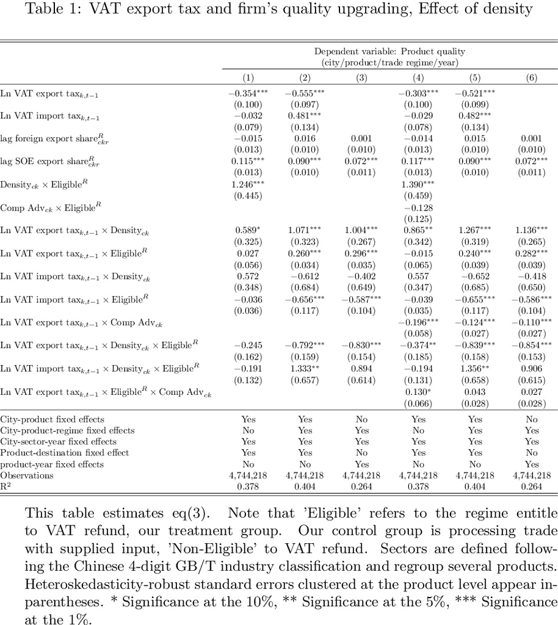

```python
reorder = {
    # Old, New
    6:4, ## Density * eligible
    10:5, ## comp * eligibile
}

tbe1  = """
This table estimates eq(3).
Note that 'Eligible' refers to the regime entitle to VAT refund, our treatment group.
Our control group is processing trade with supplied input, 'Non-Eligible' to VAT refund.
Sectors are defined following the Chinese 4-digit GB/T industry
classification and regroup several products.
Heteroskedasticity-robust standard errors
clustered at the product level appear inparentheses.
\sym{*} Significance at the 10\%, \sym{**} Significance at the 5\%, \sym{***} Significance at the 1\%."""

multicolumn ={
    '': 1,
    'Eligible': 1,
    'Non-Eligible': 1,
    '': 1,
}
multi_lines_dep = '(city/product/trade regime/year)'
#new_r = ['& Eligible', 'Non-Eligible', 'All', 'All benchmark']
lb.beautify(table_number = 8,
            #multi_lines_dep = None,
            multi_lines_dep = multi_lines_dep,
            new_row= False,
            multicolumn = None,
            reorder_var = reorder,
            table_nte = tbe1,
            jupyter_preview = True,
            resolution = 200)
```

# Generate reports

```python
import os, time, shutil, urllib, ipykernel, json
from pathlib import Path
from notebook import notebookapp
```

```python
def create_report(extension = "html", keep_code = False):
    """
    Create a report from the current notebook and save it in the
    Report folder (Parent-> child directory)

    1. Exctract the current notbook name
    2. Convert the Notebook
    3. Move the newly created report

    Args:
    extension: string. Can be "html", "pdf", "md"


    """

    ### Get notebook name
    connection_file = os.path.basename(ipykernel.get_connection_file())
    kernel_id = connection_file.split('-', 1)[0].split('.')[0]

    for srv in notebookapp.list_running_servers():
        try:
            if srv['token']=='' and not srv['password']:
                req = urllib.request.urlopen(srv['url']+'api/sessions')
            else:
                req = urllib.request.urlopen(srv['url']+ \
                                             'api/sessions?token=' + \
                                             srv['token'])
            sessions = json.load(req)
            notebookname = sessions[0]['name']
        except:
            pass

    sep = '.'
    path = os.getcwd()
    #parent_path = str(Path(path).parent)

    ### Path report
    #path_report = "{}/Reports".format(parent_path)
    #path_report = "{}/Reports".format(path)

    ### Path destination
    name_no_extension = notebookname.split(sep, 1)[0]
    source_to_move = name_no_extension +'.{}'.format(extension)
    dest = os.path.join(path,'Reports', source_to_move)

    ### Generate notebook
    if keep_code:
        os.system('jupyter nbconvert --to {} {}'.format(
    extension,notebookname))
    else:
        os.system('jupyter nbconvert --no-input --to {} {}'.format(
    extension,notebookname))

    ### Move notebook to report folder
    #time.sleep(5)
    shutil.move(source_to_move, dest)
    print("Report Available at this adress:\n {}".format(dest))
```

```python
create_report(extension = "html", keep_code = True)
```

```
Report Available at this adress:
 /Users/thomas/Google Drive/Projects/GitHub/Repositories/VAT_rebate_quality_china/02_data_analysis/00_analysis/02_analysis_table_3_POC/Reports/00_empirical_density.html
```